# Refinando o estilo do matplotlib com seaborn

#### Wilson Freitas

23/06/2014

Categoria: [data science](https://wilsonfreitas.github.io/category/data-science.html)

Tags: [python](https://wilsonfreitas.github.io/tag/python.html) [visualization](https://wilsonfreitas.github.io/tag/visualization.html) [seaborn](https://wilsonfreitas.github.io/tag/seaborn.html) [matplotlib](https://wilsonfreitas.github.io/tag/matplotlib.html)

No post [Refinando a apresentação do matplotlib](https://wilsonfreitas.github.io/posts/refinando-o-estilo-do-matplotlib.html) eu mostrei como melhorar o *layout* dos gráficos do **matplotlib** utilizando o **seaborn**. Continuando com as dicas para refinar a apresentação dos gráficos em matplotlib vou mostrar como construir um gráfico mais científico, semelhante aos que aparecem em livros de cálculo da graduação. Para isso vou apresentar as funções `despine` e `offset_spines` do **seaborn** e algumas de suas opções.

O *layout* padrão coloca os gráficos em uma caixa, como se fosse uma borda. No entanto, alguns gráficos ficam mais atrativos quando colocamos apenas o eixo x-y, sem a caixa, ou ainda sem as bordas e com linhas de grade em tom suave.

Vamos começar observando o gráfico abaixo de uma série temporal sintética simulando um processo estocástico geométrico sem coeficiente linear (*drift*).

```python
import seaborn as sn
sn.set_context("talk")

ts = cumprod(exp(random.randn(200)*0.02))
```

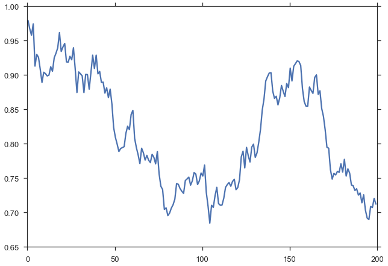

```python
sn.set_style("ticks")
plot(ts);
```

No gráfico acima temos os *ticks* no eixo y que delimitam os níveis. Uma informação interessante de se obter visualmente é a duração da série em determinadas faixas. No gráfico acima essa informação está presente mas não está clara. Uma forma de se obter isso é a criação de linhas de grade (*grids*).

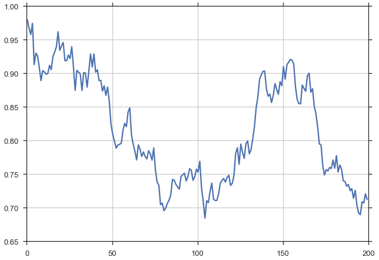

```python
plot(ts)
grid();
```

A inclusão de linhas de grade ajudam a melhorar a interpretação do gráfico ficando fácil observar os intervalos de oscilação da série temporal. Com a inclusão das grades podemos observar com detalhes quando a série ultrapassa as linhas de grade. Para séries temporais longas, onde a observação temporal é relevante essa funcionalidade ajuda na interpretação do gráfico.

Para melhorar a visualização vou remover a caixa usando a função `despine` e manter as linhas de grade apenas para o eixo y.

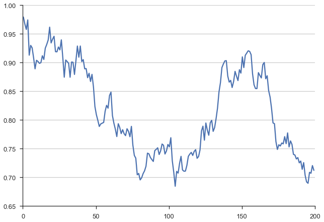

```python
plot(ts)
sn.despine()
grid(axis='y')
```

Agora vou remover o eixo y mantendo as linhas de grade para ressaltar os níveis de oscilação.

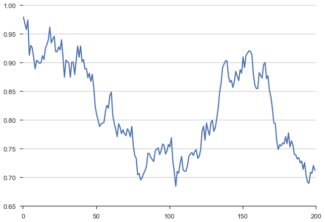

```python
plot(ts)
sn.despine(left=True)
grid(axis='y')
```

Para destacar ainda mais os dados vou desacolplar os eixos do gráfico realçando as linhas de grade. A função `offset_spines` desloca os eixos do gráfico uma quantidade de pontos. Na função `despine` usamos o argumento `bottom=True` para remover o eixo x, mantendo as marcas (*ticks*).

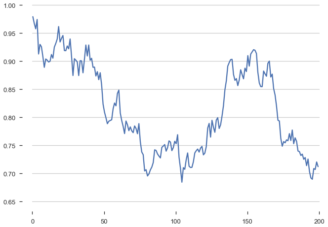

```python
plot(ts)
sn.offset_spines(20)
sn.despine(left=True, bottom=True)
grid(axis='y')
```

Ou ainda removendo os *ticks*, para isso definimos os estilo como `whitegrid`.

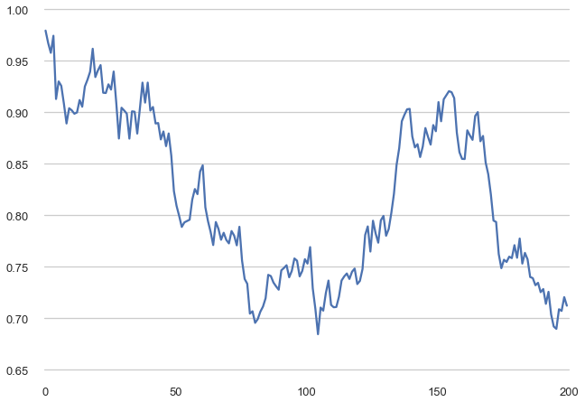

```python
sn.set_style("whitegrid")
plot(ts)
sn.offset_spines()
sn.despine(left=True, bottom=True)
grid(False, axis='x')
```

Note que agora tivemos que retirar as linhas de grade referentes ao eixo x (`grid(False, axis='x')`), dado que o estilo já define linhas de grade.

## Conclusão

Francamente nem sei como reproduzir essas funcionalidades utilizando apenas o **matplotlib**, no tutorial do **seaborn** eles mencionam que não seria possível fazer isso utilizando os parâmetros do matplotlib, acho que cabe uma verificação.

As funções `despine` e `offset_spines` permitem enriquecer a visualização dos gráficos com comandos simples e intuitivos. Estes ajustes são importantes para que você destaque nos gráficos a informação que se acredita relevante. Afinal, esse é um dos objetivos da visualização, melhorar a comunicação. A informação já está lá você somente precisa fazer com que ela seja mais facilmente digerida.

Abaixo segue uma aplicação prática do que acabamos de discutir. Um gráfico de rentabilidade de ativos (PETR4 e BOVA11) contra o CDI (um investimento em renda fixa, CDB por exemplo). Note que mesmo com a maré ruim do mercado ambos os ativos bateram o CDI nos primeiros 6 meses do ano (2014).

```
No authentication tokens found: usage will be limited.
See www.quandl.com/api for more information.
Returning Dataframe for  [u'GOOG.BVMF_PETR4.4', u'GOOG.BVMF_BOVA11.4', u'BCB.12']
```

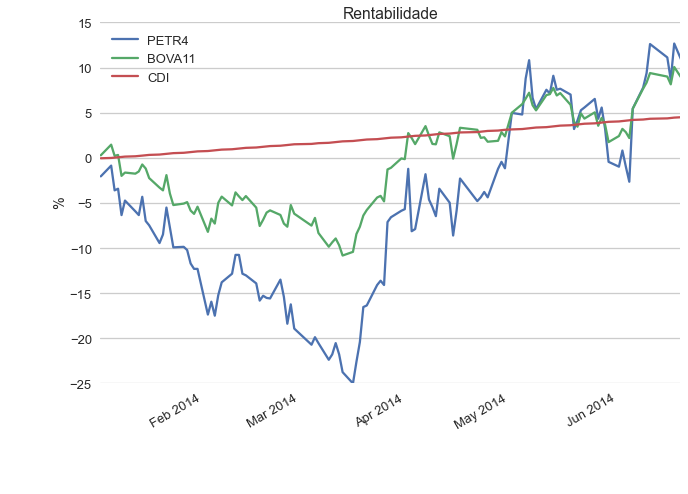

```python
import Quandl

# baixando os dados - a partir do começo do ano
ts = Quandl.get(["GOOG/BVMF_PETR4.4", "GOOG/BVMF_BOVA11.4", "BCB/12"], trim_start='2014-01-01')
ts = ts.rename(columns={'GOOG.BVMF_PETR4 - Close': 'PETR4', 'GOOG.BVMF_BOVA11 - Close': 'BOVA11',
                   'BCB.12 - Value': 'CDI'})

# separando ações da taxa de juros
stocks = ts.drop('CDI', 1)
cdi = ts.CDI/100 # as taxas de juros vem em unidades %

# calculando a variação percentual das ações
varp = exp(log(stocks).diff()) - 1
varp = varp.dropna() # removendo os NaN

# juntando com o CDI e calculando a variação percentual acumulada
varp = varp.join(cdi) + 1
varp = (varp.cumprod() - 1)*100

# montando o gráfico
varp.plot()
sn.despine(left=True, bottom=True)
grid(False, axis='x')
title('Rentabilidade')
ylabel('%')
xlabel('');
```

## Comments

© Wilson Freitas 2015-2018

Powered by Pelican